# Group10_Cute2

Broto Bhattacharjee

June 1, 2018

# Clear environment

```r
rm(list = ls(all=TRUE))
```

# Load required R library

```r
library(stringr)
library(vegan)
library(ROCR)
library(zoo)
library(dplyr)
library(TTR)
library(forecast)
library(DMwR)
library(data.table)
```

# Set working directory

```r
setwd("C://Users//brbhatta//Desktop//INSOFE//Cute2")
```

# Read the dataset

```r
train_data <- read.csv(file = "train_data.csv", header = TRUE)
test_data <- read.csv(file = "test_data.csv", header = TRUE)
```

# Explore and understand the data

Head

```r
head(train_data)
```

```
##   index age working_sector financial_weight qualification
## 1     1  39          state            77516     Bachelors
## 2     2  50  self_employed            83311     Bachelors
## 3     3  38        private           215646       HS-grad
## 4     4  53        private           234721          11th
## 5     5  28        private           338409     Bachelors
## 6     6  37        private           284582       Masters
##   years_of_education tax_paid loan_taken   marital_status occupation
## 1                 13       NA          0    Never-married   clerical
## 2                 13       NA          0 Married-civilian managerial
## 3                  9       NA          0         Divorced    cleaner
## 4                  7       NA          0 Married-civilian    cleaner
## 5                 13       NA          0 Married-civilian  specialty
## 6                 14       NA          0 Married-civilian managerial
##     relationship ethnicity  gender gain loss working_hours        country
## 1  Not-in-family     White    Male 2174    0            40  United-States
## 2        Husband     White    Male    0    0            13  United-States
## 3  Not-in-family     White    Male    0    0            40  United-States
## 4        Husband     Black    Male    0    0            40  United-States
## 5           Wife     Black  Female    0    0            40           Cuba
## 6           Wife     White  Female    0    0            40  United-States
##   target
## 1      0
## 2      0
## 3      0
## 4      0
## 5      0
## 6      0
```

Tail

```r
tail(train_data)
```

```
##       index age working_sector financial_weight qualification
## 31582 31582  22        private           310152  Some-college
## 31583 31583  27        private           257302    Assoc-acdm
## 31584 31584  40        private           154374       HS-grad
## 31585 31585  58        private           151910       HS-grad
## 31586 31586  22        private           201490       HS-grad
## 31587 31587  52  self_employed           287927       HS-grad
##       years_of_education tax_paid loan_taken   marital_status occupation
## 31582                 10       NA          0    Never-married      guard
## 31583                 12       NA          0 Married-civilian    support
## 31584                  9       NA          0 Married-civilian  inspector
## 31585                  9       NA          0          Widowed   clerical
## 31586                  9 7727.924          1    Never-married   clerical
## 31587                  9       NA          0 Married-civilian managerial
##         relationship ethnicity  gender  gain loss working_hours
## 31582  Not-in-family     White    Male     0    0            40
## 31583           Wife     White  Female     0    0            38
## 31584        Husband     White    Male     0    0            40
## 31585      Unmarried     White  Female     0    0            40
## 31586      Own-child     White    Male     0    0            20
## 31587           Wife     White  Female 15024    0            40
##              country target
## 31582  United-States      0
## 31583  United-States      0
## 31584  United-States      1
## 31585  United-States      0
## 31586  United-States      0
## 31587  United-States      1
```

Structure

```r
str(train_data)
```

```
## 'data.frame':    31587 obs. of  18 variables:
##  $ index             : int  1 2 3 4 5 6 7 8 9 10 ...
##  $ age               : int  39 50 38 53 28 37 49 52 31 42 ...
##  $ working_sector    : Factor w/ 7 levels "local_body","national",..: 6 5 4 4 4 4 4 5 4 4 ...
##  $ financial_weight  : int  77516 83311 215646 234721 338409 284582 160187 209642 45781 159449 ...
##  $ qualification     : Factor w/ 16 levels " 10th"," 11th",..: 10 10 12 2 10 13 7 12 13 10 ...
##  $ years_of_education: int  13 13 9 7 13 14 5 9 14 13 ...
##  $ tax_paid          : num  NA NA NA NA NA ...
##  $ loan_taken        : int  0 0 0 0 0 0 0 1 0 0 ...
##  $ marital_status    : Factor w/ 7 levels "Divorced","Married-civilian",..: 5 2 1 2 2 2 4 2 5 2 ...
##  $ occupation        : Factor w/ 14 levels "cleaner","clerical",..: 2 8 1 1 12 8 9 8 12 8 ...
##  $ relationship      : Factor w/ 6 levels " Husband"," Not-in-family",..: 2 1 2 1 6 6 2 1 2 1 ...
##  $ ethnicity         : Factor w/ 5 levels " Amer-Indian-Eskimo",..: 5 5 5 3 3 5 3 5 5 5 ...
##  $ gender            : Factor w/ 2 levels " Female"," Male": 2 2 2 2 1 1 1 2 1 2 ...
##  $ gain              : int  2174 0 0 0 0 0 0 0 14084 5178 ...
##  $ loss              : int  0 0 0 0 0 0 0 0 0 0 ...
##  $ working_hours     : int  40 13 40 40 40 40 16 45 50 40 ...
##  $ country           : Factor w/ 41 levels " Cambodia"," Canada",..: 39 39 39 39 5 39 23 39 39 39 ...
##  $ target            : int  0 0 0 0 0 0 0 1 1 1 ...
```

Summary

```r
summary(train_data)
```

```
##      index            age              working_sector  financial_weight
##  Min.   :    1   Min.   :17.00   private      :22033   Min.   :  12285
##  1st Qu.: 7898   1st Qu.:28.00   self_employed: 3543   1st Qu.: 117881
##  Median :15794   Median :37.00   local_body   : 2019   Median : 178564
##  Mean   :15794   Mean   :38.56   state        : 1274   Mean   : 189976
##  3rd Qu.:23691   3rd Qu.:48.00   national     :  923   3rd Qu.: 237466
##  Max.   :31587   Max.   :90.00   (Other)      :   20   Max.   :1484705
##                  NA's   :2       NA's         : 1775   NA's   :2
##        qualification   years_of_education    tax_paid
##   HS-grad     :10198   Min.   : 1.00      Min.   :2010
##   Some-college: 7078   1st Qu.: 9.00      1st Qu.:5004
##   Bachelors   : 5196   Median :10.00      Median :6382
##   Masters     : 1665   Mean   :10.08      Mean   :6286
##   Assoc-voc   : 1336   3rd Qu.:12.00      3rd Qu.:7968
##  (Other)      : 6112   Max.   :16.00      Max.   :9998
##  NA's         :    2                      NA's   :29206
##    loan_taken                   marital_status       occupation
##  Min.   :0.00000   Divorced            : 4299   specialty : 3997
##  1st Qu.:0.00000   Married-civilian    :14540   repair    : 3975
##  Median :0.00000   Married-defence     :   23   managerial: 3943
##  Mean   :0.05024   Married-non-resident:  403   clerical  : 3658
##  3rd Qu.:0.00000   Never-married       :10374   sales     : 3558
##  Max.   :1.00000   Separated           :  987   (Other)   :10674
##                    Widowed             :  961   NA's      : 1782
##           relationship                 ethnicity         gender
##   Husband       :12815    Amer-Indian-Eskimo:  293    Female:10449
##   Not-in-family : 8038    Asian-Pac-Islander: 1004    Male  :21136
##   Other-relative:  952    Black             : 3028   NA's   :    2
##   Own-child     : 4919    Other             :  262
##   Unmarried     : 3340    White             :26998
##   Wife          : 1521   NA's               :    2
##  NA's           :    2
##       gain            loss         working_hours             country
##  Min.   :    0   Min.   :   0.00   Min.   : 1.00    United-States:28295
##  1st Qu.:    0   1st Qu.:   0.00   1st Qu.:40.00    Mexico       :  623
##  Median :    0   Median :   0.00   Median :40.00    Philippines  :  193
##  Mean   : 1090   Mean   :  87.17   Mean   :40.44    Germany      :  133
##  3rd Qu.:    0   3rd Qu.:   0.00   3rd Qu.:45.00    Canada       :  117
##  Max.   :99999   Max.   :4356.00   Max.   :99.00   (Other)       : 1658
##  NA's   :2       NA's   :2         NA's   :2       NA's          :  568
##      target
##  Min.   :0.0000
##  1st Qu.:0.0000
##  Median :0.0000
##  Mean   :0.2412
##  3rd Qu.:0.0000
##  Max.   :1.0000
##
```

Find NA values

```r
sum(is.na(train_data)) # Total NA Values = 33349
```

```
## [1] 33349
```

Find rows where most of the columns are NA

```r
Rows_Age_NA <- subset(train_data, is.na(train_data$age))
Rows_Age_NA
```

```
##       index age working_sector financial_weight qualification
## 31561 31561  NA           <NA>               NA          <NA>
## 31572 31572  NA           <NA>               NA          <NA>
##       years_of_education tax_paid loan_taken marital_status occupation
## 31561                 12       NA          0      Separated       <NA>
## 31572                 10       NA          0       Divorced       <NA>
##       relationship ethnicity gender gain loss working_hours country target
## 31561         <NA>      <NA>   <NA>   NA   NA            NA    <NA>      1
## 31572         <NA>      <NA>   <NA>   NA   NA            NA    <NA>      1
```

- We see above that there are 2 rows where 13 out of 18 columns are NA. So we do not consider these 2 rows while creating our model.

```r
train_data <- subset(train_data, train_data$age != 'NA')
summary(train_data)
```

```
##      index            age              working_sector  financial_weight
##  Min.   :    1   Min.   :17.00   private      :22033   Min.   :  12285
##  1st Qu.: 7897   1st Qu.:28.00   self_employed: 3543   1st Qu.: 117881
##  Median :15793   Median :37.00   local_body   : 2019   Median : 178564
##  Mean   :15793   Mean   :38.56   state        : 1274   Mean   : 189976
##  3rd Qu.:23689   3rd Qu.:48.00   national     :  923   3rd Qu.: 237466
##  Max.   :31587   Max.   :90.00   (Other)      :   20   Max.   :1484705
##                                  NA's         : 1773
##        qualification   years_of_education    tax_paid
##   HS-grad     :10198   Min.   : 1.00      Min.   :2010
##   Some-college: 7078   1st Qu.: 9.00      1st Qu.:5004
##   Bachelors   : 5196   Median :10.00      Median :6382
##   Masters     : 1665   Mean   :10.08      Mean   :6286
##   Assoc-voc   : 1336   3rd Qu.:12.00      3rd Qu.:7968
##   11th        : 1138   Max.   :16.00      Max.   :9998
##  (Other)      : 4974                      NA's   :29204
##    loan_taken                   marital_status       occupation
##  Min.   :0.00000   Divorced            : 4298   specialty : 3997
##  1st Qu.:0.00000   Married-civilian    :14540   repair    : 3975
##  Median :0.00000   Married-defence     :   23   managerial: 3943
##  Mean   :0.05025   Married-non-resident:  403   clerical  : 3658
##  3rd Qu.:0.00000   Never-married       :10374   sales     : 3558
##  Max.   :1.00000   Separated           :  986   (Other)   :10674
##                    Widowed             :  961   NA's      : 1780
##           relationship                 ethnicity         gender
##   Husband       :12815    Amer-Indian-Eskimo:  293    Female:10449
##   Not-in-family : 8038    Asian-Pac-Islander: 1004    Male  :21136
##   Other-relative:  952    Black             : 3028
##   Own-child     : 4919    Other             :  262
##   Unmarried     : 3340    White             :26998
##   Wife          : 1521
##
##       gain            loss         working_hours             country
##  Min.   :    0   Min.   :   0.00   Min.   : 1.00    United-States:28295
##  1st Qu.:    0   1st Qu.:   0.00   1st Qu.:40.00    Mexico       :  623
##  Median :    0   Median :   0.00   Median :40.00    Philippines  :  193
##  Mean   : 1090   Mean   :  87.17   Mean   :40.44    Germany      :  133
##  3rd Qu.:    0   3rd Qu.:   0.00   3rd Qu.:45.00    Canada       :  117
##  Max.   :99999   Max.   :4356.00   Max.   :99.00   (Other)       : 1658
##                                                    NA's          :  566
##      target
##  Min.   :0.0000
##  1st Qu.:0.0000
##  Median :0.0000
##  Mean   :0.2412
##  3rd Qu.:0.0000
##  Max.   :1.0000
##
```

# See the mode of the columns which have NA values

- Write a function for calculating Mode

```r
Mode <- function(x) {
  ux <- unique(x)
  ux[which.max(tabulate(match(x, ux)))]
}
```

See the Mode of NA columns in train_data

```r
Mode(train_data$working_sector)
```

```
## [1] private
## 7 Levels: local_body national not_worked private self_employed ... without_pay
```

```r
Mode(train_data$occupation)
```

```
## [1] specialty
## 14 Levels: cleaner clerical defence farming guard ... transport
```

```r
Mode(train_data$country)
```

```
## [1]  United-States
## 41 Levels:  Cambodia  Canada  China  Columbia ...  Yugoslavia
```

See the Mode of NA columns in test_data

```r
Mode(test_data$working_sector)
```

```
## [1] private
## Levels: local_body national private self_employed state without_pay
```

```r
Mode(test_data$occupation)
```

```
## [1] specialty
## 13 Levels: cleaner clerical farming guard house_servant ... transport
```

```r
Mode(test_data$country)
```

```
## [1]  United-States
## 34 Levels:  Cambodia  Canada  China  Columbia ...  Yugoslavia
```

Impute working_sector, occupation, country with Mode in train_data

```r
train_data$working_sector[is.na(train_data$working_sector)] <- Mode(train_data$working_sector)
train_data$occupation[is.na(train_data$occupation)] <- Mode(train_data$occupation)
train_data$country[is.na(train_data$country)] <- Mode(train_data$country)
```

Impute tax_paid with 0

```r
train_data$tax_paid[is.na(train_data$tax_paid)] <- 0

# Check if there are any NA values
sum(is.na(train_data$working_sector))
```

```
## [1] 0
```

```r
sum(is.na(train_data$occupation))
```

```
## [1] 0
```

```r
sum(is.na(train_data$country))
```

```
## [1] 0
```

```r
sum(is.na(train_data$tax_paid))
```

```
## [1] 0
```

# See the summary of train_data after imputing

```r
summary(train_data)
```

```
##      index            age              working_sector  financial_weight
##  Min.   :    1   Min.   :17.00   local_body   : 2019   Min.   :  12285
##  1st Qu.: 7897   1st Qu.:28.00   national     :  923   1st Qu.: 117881
##  Median :15793   Median :37.00   not_worked   :    7   Median : 178564
##  Mean   :15793   Mean   :38.56   private      :23806   Mean   : 189976
##  3rd Qu.:23689   3rd Qu.:48.00   self_employed: 3543   3rd Qu.: 237466
##  Max.   :31587   Max.   :90.00   state        : 1274   Max.   :1484705
##                                  without_pay  :   13
##        qualification   years_of_education    tax_paid
##   HS-grad     :10198   Min.   : 1.00      Min.   :   0.0
##   Some-college: 7078   1st Qu.: 9.00      1st Qu.:   0.0
##   Bachelors   : 5196   Median :10.00      Median :   0.0
##   Masters     : 1665   Mean   :10.08      Mean   : 473.9
##   Assoc-voc   : 1336   3rd Qu.:12.00      3rd Qu.:   0.0
##   11th        : 1138   Max.   :16.00      Max.   :9997.8
##  (Other)      : 4974
##    loan_taken                   marital_status       occupation
##  Min.   :0.00000   Divorced            : 4298   specialty :5777
##  1st Qu.:0.00000   Married-civilian    :14540   repair    :3975
##  Median :0.00000   Married-defence     :   23   managerial:3943
##  Mean   :0.05025   Married-non-resident:  403   clerical  :3658
##  3rd Qu.:0.00000   Never-married       :10374   sales     :3558
##  Max.   :1.00000   Separated           :  986   other     :3214
##                    Widowed             :  961   (Other)   :7460
##           relationship                 ethnicity         gender
##   Husband       :12815    Amer-Indian-Eskimo:  293    Female:10449
##   Not-in-family : 8038    Asian-Pac-Islander: 1004    Male  :21136
##   Other-relative:  952    Black             : 3028
##   Own-child     : 4919    Other             :  262
##   Unmarried     : 3340    White             :26998
##   Wife          : 1521
##
##       gain            loss         working_hours             country
##  Min.   :    0   Min.   :   0.00   Min.   : 1.00    United-States:28861
##  1st Qu.:    0   1st Qu.:   0.00   1st Qu.:40.00    Mexico       :  623
##  Median :    0   Median :   0.00   Median :40.00    Philippines  :  193
##  Mean   : 1090   Mean   :  87.17   Mean   :40.44    Germany      :  133
##  3rd Qu.:    0   3rd Qu.:   0.00   3rd Qu.:45.00    Canada       :  117
##  Max.   :99999   Max.   :4356.00   Max.   :99.00    Puerto-Rico  :  112
##                                                    (Other)       : 1546
##      target
##  Min.   :0.0000
##  1st Qu.:0.0000
##  Median :0.0000
##  Mean   :0.2412
##  3rd Qu.:0.0000
##  Max.   :1.0000
##
```

# Standardize numerical attributes

```r
Data_NumAtr <- subset(x=train_data, select=c(age, financial_weight, years_of_education, gain, loss, working_hours))
Std_Data <- decostand(x = Data_NumAtr, method = "range")
```

# Include the categorical attributes again without ‘index’ column

```r
Std_Data$working_sector <- train_data$working_sector
Std_Data$qualification <- train_data$qualification
Std_Data$loan_taken <- train_data$loan_taken
Std_Data$marital_status <- train_data$marital_status
Std_Data$occupation <- train_data$occupation
Std_Data$relationship <- train_data$relationship
Std_Data$ethnicity <- train_data$ethnicity
Std_Data$gender <- train_data$gender
Std_Data$country <- train_data$country
Std_Data$y <- train_data$target
```

# See the summary of Std_Data

```r
summary(Std_Data)
```

```
##       age         financial_weight  years_of_education      gain
##  Min.   :0.0000   Min.   :0.00000   Min.   :0.0000     Min.   :0.0000
##  1st Qu.:0.1507   1st Qu.:0.07172   1st Qu.:0.5333     1st Qu.:0.0000
##  Median :0.2740   Median :0.11293   Median :0.6000     Median :0.0000
##  Mean   :0.2953   Mean   :0.12068   Mean   :0.6053     Mean   :0.0109
##  3rd Qu.:0.4247   3rd Qu.:0.15293   3rd Qu.:0.7333     3rd Qu.:0.0000
##  Max.   :1.0000   Max.   :1.00000   Max.   :1.0000     Max.   :1.0000
##
##       loss         working_hours          working_sector
##  Min.   :0.00000   Min.   :0.0000   local_body   : 2019
##  1st Qu.:0.00000   1st Qu.:0.3980   national     :  923
##  Median :0.00000   Median :0.3980   not_worked   :    7
##  Mean   :0.02001   Mean   :0.4024   private      :23806
##  3rd Qu.:0.00000   3rd Qu.:0.4490   self_employed: 3543
##  Max.   :1.00000   Max.   :1.0000   state        : 1274
##                                     without_pay  :   13
##        qualification     loan_taken                   marital_status
##   HS-grad     :10198   Min.   :0.00000   Divorced            : 4298
##   Some-college: 7078   1st Qu.:0.00000   Married-civilian    :14540
##   Bachelors   : 5196   Median :0.00000   Married-defence     :   23
##   Masters     : 1665   Mean   :0.05025   Married-non-resident:  403
##   Assoc-voc   : 1336   3rd Qu.:0.00000   Never-married       :10374
##   11th        : 1138   Max.   :1.00000   Separated           :  986
##  (Other)      : 4974                     Widowed             :  961
##       occupation            relationship                 ethnicity
##  specialty :5777    Husband       :12815    Amer-Indian-Eskimo:  293
##  repair    :3975    Not-in-family : 8038    Asian-Pac-Islander: 1004
##  managerial:3943    Other-relative:  952    Black             : 3028
##  clerical  :3658    Own-child     : 4919    Other             :  262
##  sales     :3558    Unmarried     : 3340    White             :26998
##  other     :3214    Wife          : 1521
##  (Other)   :7460
##      gender                country            y
##   Female:10449    United-States:28861   Min.   :0.0000
##   Male  :21136    Mexico       :  623   1st Qu.:0.0000
##                   Philippines  :  193   Median :0.0000
##                   Germany      :  133   Mean   :0.2412
##                   Canada       :  117   3rd Qu.:0.0000
##                   Puerto-Rico  :  112   Max.   :1.0000
##                  (Other)       : 1546
```

```r
dim(Std_Data)
```

```
## [1] 31585    16
```

```r
dim(train_data)
```

```
## [1] 31585    18
```

# Creating the logistic regression model

```r
log_reg <- glm(y~., data = Std_Data, family = binomial)
```

# See the summary of Logistic Regression

```r
summary(log_reg)
```

```
##
## Call:
## glm(formula = y ~ ., family = binomial, data = Std_Data)
##
## Deviance Residuals:
##     Min       1Q   Median       3Q      Max
## -5.1253  -0.5085  -0.1852  -0.0244   3.7073
##
## Coefficients: (1 not defined because of singularities)
##                                     Estimate Std. Error z value Pr(>|z|)
## (Intercept)                         -8.36495    0.84077  -9.949  < 2e-16
## age                                  1.67062    0.11978  13.947  < 2e-16
## financial_weight                     0.88319    0.25548   3.457 0.000546
## years_of_education                   4.29001    0.58465   7.338 2.17e-13
## gain                                31.94244    1.03836  30.762  < 2e-16
## loss                                 2.83627    0.16388  17.307  < 2e-16
## working_hours                        3.17209    0.15863  19.997  < 2e-16
## working_sectornational               0.65079    0.11392   5.713 1.11e-08
## working_sectornot_worked           -11.21558  272.22563  -0.041 0.967137
## working_sectorprivate                0.07316    0.07304   1.002 0.316511
## working_sectorself_employed         -0.14950    0.08631  -1.732 0.083264
## working_sectorstate                 -0.12051    0.10799  -1.116 0.264447
## working_sectorwithout_pay          -12.58839  202.62725  -0.062 0.950463
## qualification 11th                  -0.23164    0.18713  -1.238 0.215784
## qualification 12th                  -0.09721    0.23244  -0.418 0.675774
## qualification 1st-4th                0.36271    0.59559   0.609 0.542523
## qualification 5th-6th                0.55713    0.39291   1.418 0.156206
## qualification 7th-8th               -0.06137    0.29118  -0.211 0.833066
## qualification 9th                    0.06564    0.28479   0.230 0.817719
## qualification Assoc-acdm            -0.36119    0.13128  -2.751 0.005936
## qualification Assoc-voc             -0.05413    0.09825  -0.551 0.581628
## qualification Bachelors             -0.01299    0.13701  -0.095 0.924441
## qualification Doctorate              0.23336    0.28916   0.807 0.419654
## qualification HS-grad               -0.07658    0.05730  -1.336 0.181404
## qualification Masters                0.10200    0.18321   0.557 0.577693
## qualification Preschool            -18.72529  257.87869  -0.073 0.942114
## qualification Prof-school            0.38458    0.24481   1.571 0.116193
## qualification Some-college                NA         NA      NA       NA
## loan_taken                          -0.08373    0.08050  -1.040 0.298278
## marital_statusMarried-civilian       2.10858    0.27073   7.788 6.79e-15
```

[output cut: 162 more lines]

```
## country Thailand                   .
## country Trinadad&Tobago
## country United-States              .
## country Vietnam                    **
## country Yugoslavia
## ---
## Signif. codes:  0 '***' 0.001 '**' 0.01 '*' 0.05 '.' 0.1 ' ' 1
##
## (Dispersion parameter for binomial family taken to be 1)
##
##     Null deviance: 34896  on 31584  degrees of freedom
## Residual deviance: 20110  on 31488  degrees of freedom
## AIC: 20304
##
## Number of Fisher Scoring iterations: 13
```

# Predicting using the logistic regression model

# Predicted Values are between 0 and 1

# The predict() function on the “glm” object of “binomial” family gives a probability score between 0 and 1, NOT the original levels (0 and 1) of the response variable

# Hence we must first choose a cutoff point for getting to the original levels of the response variables

# To choose the cutoff point we will use the train data, as test data should not be used to make any decisions regarding the model

# **Steps to create an ROC plot :**

# 1) Get a list of predictions (probability scores) using the predict() function

# Use the argument ‘type = “response”’ in the predict function to get a list of predictions between 0 and 1

# By default if no dataset is mentioned, training data is used

```r
prob_train <- predict(log_reg, type = "response")
```

# Summary of prob_train

```r
summary(prob_train)
```

```
##    Min. 1st Qu.  Median    Mean 3rd Qu.    Max.
## 0.00000 0.01552 0.10361 0.24116 0.39246 1.00000
```

# The prediction object takes the probability scores and the original levels for theses data as input

# 2) Using the ROCR package create a “prediction()” object

# The prediction object contains a list of predictions (probability scores),

# original class labels, cutoffs, false positives, true positives, true negatives, false negatives,

# No. of positive predictions and No. of negative predictions corresponding to these cutoffs. Class distribution in the dataset.

```r
pred <- prediction(prob_train, Std_Data$y)
```

# Summary of pred

```r
summary(pred)
```

```
##     Length      Class       Mode
##          1 prediction         S4
```

# As it is S4 class OOP in R we can call a value using ‘@’

```r
#pred@predictions
#pred@labels
#pred@cutoffs
```

# 3) Extract performance measures (True Positive Rate and False Positive Rate) using the “performance()” function from the ROCR package

```r
# The performance() function from the ROCR package helps us extract metrics such as True positive rate, False positive rate etc. from the prediction object, we created above.

# Two measures (y-axis = tpr, x-axis = fpr) are extracted
perf <- performance(pred, measure = "tpr", x.measure = "fpr")
```

# 4) Plot the ROC curve using the extracted performance measures (TPR and FPR)

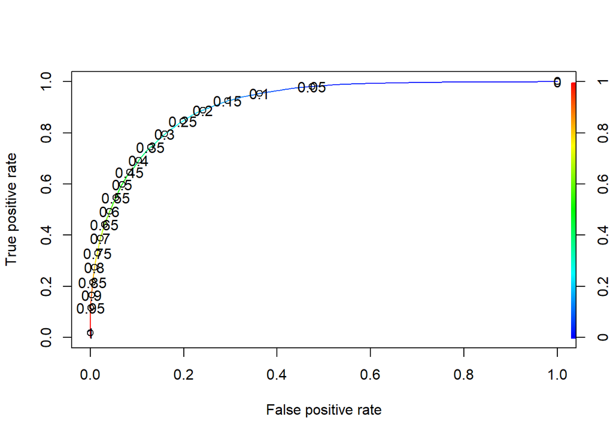

```r
plot(perf, col=rainbow(10), colorize = T, print.cutoffs.at = seq(0,1,0.05))
```

- Extract the AUC score of the ROC curve and store it in a variable named “auc”
- Use the performance() function on the prediction object created above using the ROCR package, to extract the AUC score

```r
# Access the auc score from the performance object

perf_auc <- performance(pred, measure = "auc")
auc <- perf_auc@y.values[[1]]

print(auc)
```

```
## [1] 0.9074352
```

# Choose a Cutoff Value

- Based on the trade off between TPR and FPR depending on the business domain, a call on the cutoff has to be made.
- A cutoff of 0.25 can be chosen, because after 0.2 true positive rate in increasing slowly, but the false positive rate is increasing rapidly

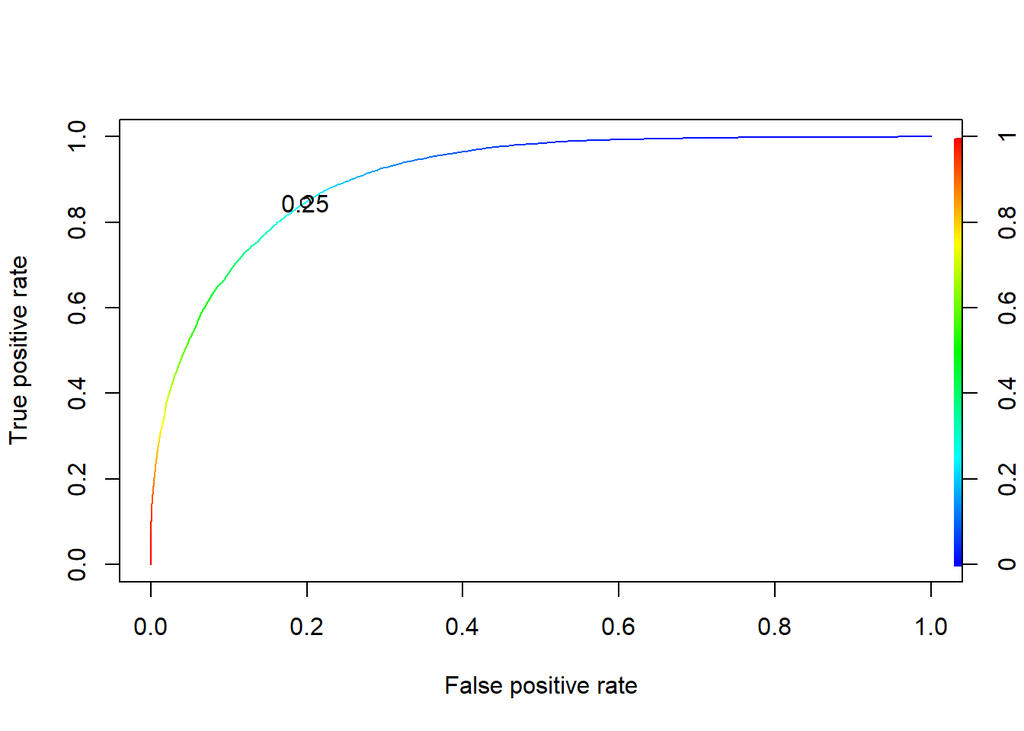

```r
plot(perf, col=rainbow(10), colorize = T, print.cutoffs.at = 0.25)
```

# Predictions on test data

- After choosing a cutoff value of 0.25, let’s predict the class labels on the test data using our model

# Look at the test_data

```r
sum(is.na(test_data))  # 947 => 947 NA values are present in test_data
```

```
## [1] 947
```

```r
summary(test_data)
```

```
##      index            age              working_sector financial_weight
##  Min.   :31588   Min.   :17.00   local_body   : 74    Min.   : 19410
##  1st Qu.:31832   1st Qu.:28.00   national     : 37    1st Qu.:114826
##  Median :32076   Median :38.00   private      :663    Median :173588
##  Mean   :32076   Mean   :39.27   self_employed:114    Mean   :183397
##  3rd Qu.:32319   3rd Qu.:48.00   state        : 24    3rd Qu.:230476
##  Max.   :32563   Max.   :90.00   without_pay  :  1    Max.   :664670
##                                  NA's         : 63
##        qualification years_of_education    tax_paid        loan_taken
##   HS-grad     :303   Min.   : 1.00      Min.   : 987.8   Min.   :0.0000
##   Some-college:213   1st Qu.: 9.00      1st Qu.:3404.7   1st Qu.:0.0000
##   Bachelors   :159   Median :10.00      Median :4840.5   Median :0.0000
##   Masters     : 58   Mean   :10.13      Mean   :4502.1   Mean   :0.0502
##   Assoc-voc   : 46   3rd Qu.:13.00      3rd Qu.:4840.9   3rd Qu.:0.0000
##   Assoc-acdm  : 39   Max.   :16.00      Max.   :9956.3   Max.   :1.0000
##  (Other)      :158                      NA's   :804
##               marital_status      occupation           relationship
##  Divorced            :145    specialty :143    Husband       :378
##  Married-civilian    :436    repair    :124    Not-in-family :267
##  Married-non-resident: 15    managerial:123    Other-relative: 29
##  Never-married       :309    clerical  :112    Own-child     :149
##  Separated           : 39    sales     : 92    Unmarried     :106
##  Widowed             : 32    (Other)   :319    Wife          : 47
##                              NA's      : 63
##                ethnicity       gender         gain
##   Amer-Indian-Eskimo: 18    Female:322   Min.   :    0.0
##   Asian-Pac-Islander: 35    Male  :654   1st Qu.:    0.0
##   Black             : 96                 Median :    0.0
##   Other             :  9                 Mean   :  672.3
##   White             :818                 3rd Qu.:    0.0
##                                          Max.   :99999.0
##
##       loss         working_hours             country
##  Min.   :   0.00   Min.   : 1.00    United-States:875
##  1st Qu.:   0.00   1st Qu.:40.00    Mexico       : 20
##  Median :   0.00   Median :40.00    Philippines  :  5
##  Mean   :  91.75   Mean   :40.37    Canada       :  4
##  3rd Qu.:   0.00   3rd Qu.:45.00    Germany      :  4
##  Max.   :2824.00   Max.   :84.00   (Other)       : 51
##                                    NA's          : 17
```